[figure not shown]

[Fig. 1] YubiKeys with support for device-bound passkeys.

March 5, 2025

# FIDO2 security key sign-in on Linux

Need to implement MFA for Linux but unsure what’s possible? This guide walks you through securing Linux logins and privilege escalation…

By Jonas Markström

5 min read

*Need to implement MFA for Linux but not sure what's possible? This guide walks you through securing Linux logins and privilege escalation with security keys as device-bound passkeys, delivering phishing resistance and a near seamless user experience.*

– Background and Scope – Prerequisites – Installation – Basic configuration – Verification – Advanced configuration – End-user experience – Further reading

### Background and Scope

Multi-Factor Authentication (MFA) is now widely accepted as essential, and we've moved past debating whether passwords should be replaced. The real challenge is choosing the *right* MFA method(s) and implementing them effectively across diverse IT environments.

Security keys, such as the YubiKey, offer a strong, phishing-resistant authentication method, supporting multiple credential types, including **FIDO2**, **U2F** and **PIV**. Moreover, with USB and NFC connectivity, they integrate seamlessly across various user endpoints.

However, translating these capabilities into a practical, organization-wide strategy can be complex. IT environments often have varied authentication *supporting* capabilities, and in some cases, a lack of visibility of options makes implementation more challenging. MFA for Linux is a prime example of where it's less clear *what* can be done, and *how*.

This guide aims to bridge the gap between what's known and what's possible. It details how to implement passwordless authentication on Linux using security keys, securing both interactive logins and privilege escalation (e.g., `su` / `sudo`) to deliver a user experience similar to modern Windows environments. The guide walks through installing the **pam-u2f** module, configuring passwordless sign-in with FIDO2 device-bound passkeys (resident keys), and exploring advanced customization options. Finally, it provides verification steps to ensure correct configuration and a smooth deployment.

📅 Last updated on: June 28 2025

### Prerequisites

*The following are prerequisites towards following this guide:*

- Linux*
- Security key *with* PIN set

*This guide uses **Ubuntu Desktop** `24.04.2` **LTS**, but feel free to try the distribution of your preference, and make sure to provide your results in the comments section of this article 🙇🏻‍♂️

[figure not shown]

### Installation

*To install the pam-u2f module:*

1. Login to the target Linux host (and open a terminal)
2. Add the requisite PPA repository to the system's package manager: `sudo add-apt-repository ppa:yubico/stable` [Fig. 2]
3. Install pam-u2f: `sudo apt-get install libpam-u2f` [Fig. 3].

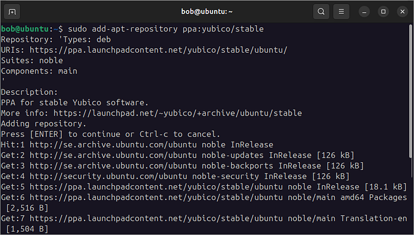

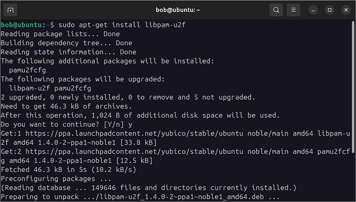

### Basic configuration

*With pam-u2f installed, let's configure it for passwordless sign-in:*

1. Make a directory: `sudo mkdir -p /etc/yubico` [Fig. 4]
2. Create a public key file: `sudo touch /etc/yubico/credentials` [Fig. 5]
3. Register a device-bound passkey (for a user called "bob"): `pamu2fcfg -ubob -r -N | sudo tee -a /etc/yubico/credentials` [Fig. 6]
4. When prompted, insert a security key, provide PIN and then touch it(!)
5. Open the PAM configuration: `sudo nano /etc/pam.d/common-auth` [Fig. 7]
6. Implement support for pam-u2f with the following line [Fig. 8]: `auth sufficient pam_u2f.so authfile=/etc/yubico/credentials cue`
7. Save exiting the file (**Ctrl** + **x** followed by **Y**).

⚠️ Before doing anything else, refer to the Verification section.

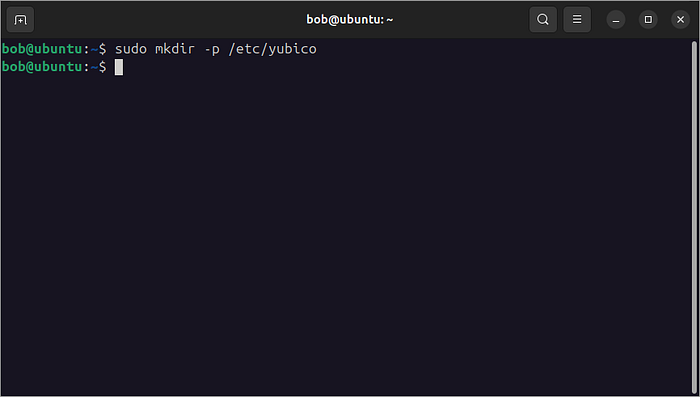

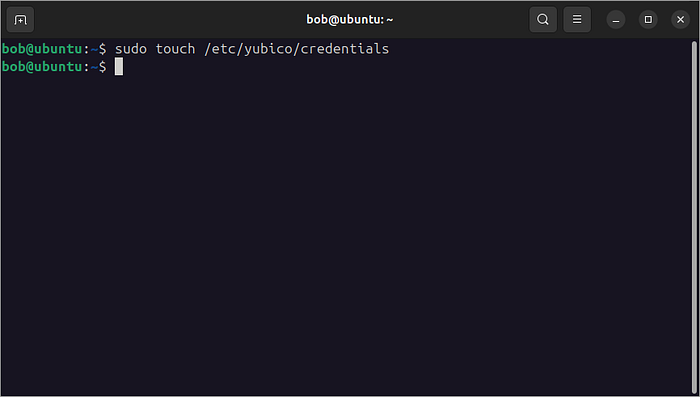

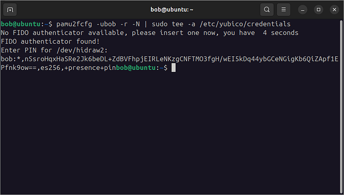

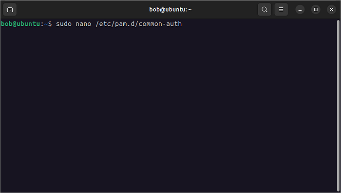

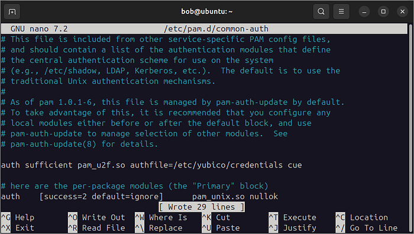

### Verification

*The following can be performed for verification or troubleshooting purposes:*

#### Confirm pam-u2f version

In order to take advantage of the latest and greatest features (and fixes), make sure you are using current version of **pam-u2f** with command: `pamu2fcfg --version` [Fig. 9]

✅ You should see version `1.4` *or* higher. If the version is lower, you might be using an older release from your distribution's repository instead of the latest stable version from Yubico.

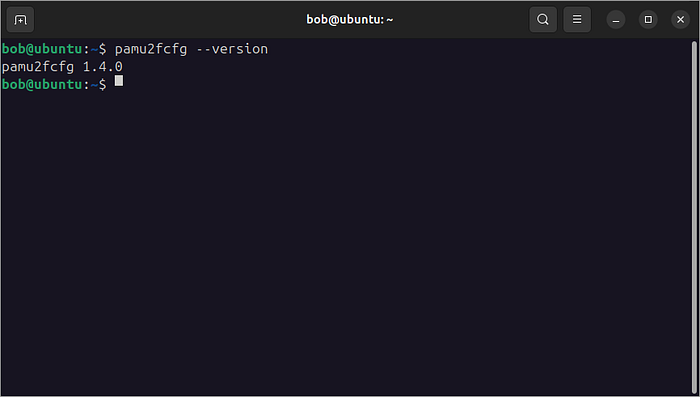

#### Verify credential creation

To confirm that a public key has been generated as part of your **pam-u2f** configuration, display the contents of the credentials file by running: `sudo cat /etc/yubico/credentials` [Fig. 10].

✅ You should see username, a credential and any requirement on User Presence and User Verification / PIN.

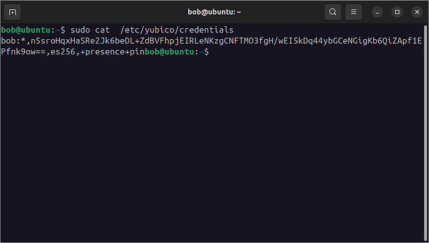

#### Verify security key authentication

To check whether security key authentication is enabled for privileged access or login, open a new terminal and run: `su bob` (replace 'bob' with the actual username) [Fig. 11].

✅ You should see a PIN prompt followed by a touch prompt.

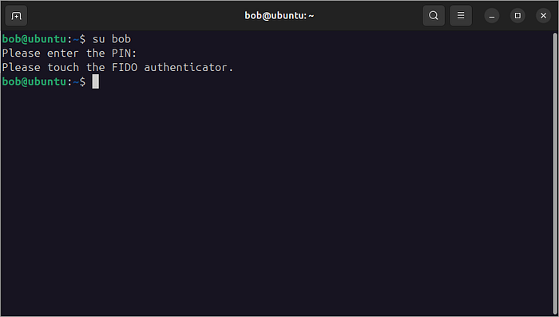

### Advanced configuration

*Assuming you have the basics working here are some additional considerations:*

#### Register a backup authenticator

**Pam-u2f** allows you to register one or more backup authenticators, which is especially important if you disable password fallback (see below). To add a second security key for a user named 'bob', run: `pamu2fcfg -ubob -r -N -n | sudo tee -a /etc/yubico/credentials` [Fig. 12].

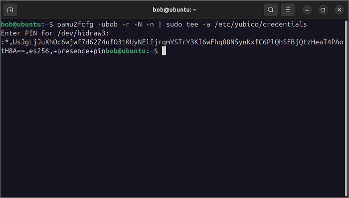

#### Enforce security key usage

While there are multiple ways to configure this, following this guide would result in PAM being set up with an `auth sufficient` statement for **pam-u2f**. This setup allows fallback to a password (or some other credential) if security key authentication fails or times out. To disable this fallback, comment out (#) the other supported authentication methods [Fig. 13].

💀 See notes on registering a backup authenticator!

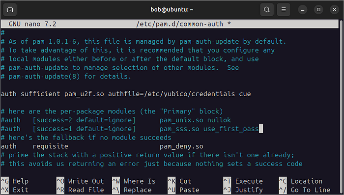

#### Support additional users

If multiple users need access to the target system, you can register security keys on their behalf. This can be done as follows (see comments):

```
# Add a primary security key for user "alice"
pamu2fcfg -ualice -r -N | sudo tee -a /etc/yubico/credentials

# Add a backup security key for user "alice"
pamu2fcfg -ualice -r -N -n | sudo tee -a /etc/yubico/credentials
```

#### Consolidating to an existing passkey credential

If enrolling security keys for users seems cumbersome — *or* if you prefer a *single* credential for all Linux access — know that it is technically possible to configure **pam-u2f** to accept a customer-defined Relying Party (RP) using the `-origin` switch. This is particularly appealing considering SSH authentication, as users may already have an SSH credential on their security key or be in scope to register one.

By consolidating pam-u2f with the [SSH credential](https://swjm.blog/the-complete-guide-to-ssh-with-fido2-security-keys-841063a04252), Linux authentication can be treated as a unified use case rather than two separate ones. This also improves the Enrollment On Behalf Of (EOBO) scenario: since the administrator can use a user's *existing* public key, there's no need for direct access to the user's YubiKey during account setup.

To streamline this process, I have created a [utility](https://github.com/JMarkstrom/fido-key-converter) that exports a YubiKey SSH public key and converts it into a pam-u2f-compatible credential. Users only need to run the tool and share the output to facilitate onboarding.

⛔ The SSH public key is not compatible with pam-u2f without conversion!

The administrator would have to add entries to the 'credentials' file as well as update the PAM configuration [Fig. 14] providing the origin as follows:

```
auth sufficient pam_u2f.so authfile=/etc/yubico/credentials cue origin=ssh:
```

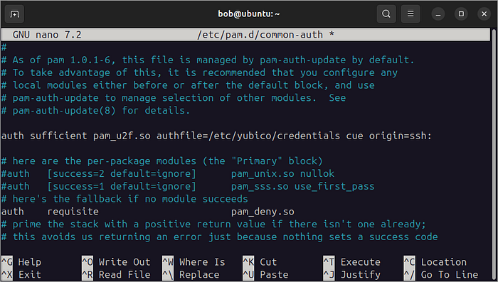

### End-user experience

On Ubuntu Desktop, the user sign-in experience appears as shown below [Fig. 15]. See the Verification section above for additional UX examples.

[figure not shown]

### Further reading

- [pam-u2f.cfg](https://developers.yubico.com/pam-u2f/Manuals/pamu2fcfg.1.html) (Yubico)
- [Yubico pam-u2f](https://github.com/Yubico/pam-u2f) (GitHub)
- [Ubuntu Linux Login Guide — U2F](https://support.yubico.com/hc/en-us/articles/360016649099-Ubuntu-Linux-Login-Guide-U2F) (Yubico)
- [The complete guide to SSH with FIDO2 security keys](https://swjm.blog/the-complete-guide-to-ssh-with-fido2-security-keys-841063a04252)
- Enabling passkey authentication in IdM environment (Red Hat)